# NYT Prediction Report

### Exploring Data

There are 8402 observations in total, where 6532 training observations and 1870 observations.

```r
popularDensity <- table(newsData$Popular)
posPopular <- round(popularDensity[2]/(popularDensity[1] + popularDensity[2]) * 100, 2)
```

Only 16.73% of all New York Times blog articles have more than 25 comments. That means, a baseline model for predicting unpopular would be around 83.27%.

The independent variables consist of 8 pieces of article data available at the time of publication, and a unique identifier:

- **NewsDesk**, the New York Times desk that produced the story (Business, Culture, Foreign, etc.)
- **SectionName**, the section the article appeared in (Opinion, Arts, Technology, etc.)
- **SubsectionName**, the subsection the article appeared in (Education, Small Business, Room for Debate, etc.)
- **Headline**, the title of the article
- **Snippet**, a small portion of the article text
- **Abstract**, a summary of the blog article, written by the New York Times
- **WordCount**, the number of words in the article
- **PubDate**, the publication date, in the format “Year-Month-Day Hour:Minute:Second”
- **UniqueID**, a unique identifier for each article

### Cleaning Data

##### Text of Articles

Let’s take a look at **Headline**, we can observe many very common combination of words like `new york times`, `pictures of the day` etc. If we google `pictures of the day new york times`, it is easy to know `pictures of the day` is a daily article from `Lens` category.

```r
newsData$Headline
```

To avoid overcounting of words like `day`, a replacement of some proper nouns to single word is necessary.

```r
originalText    = c("new york times", "new york city", "new york", "silicon valley",
                    "times insider", "fashion week", "white house",
                    "international herald tribune archive",
                    "president obama", "hong kong", "big data", "golden globe",
                    "word of the day", "time square", "pictures of the day",
                    "photos of the day", "daily clip report", "daily report",
                    "6 q's about the news", "test yourself")

replacementText = c("NYT", "NYC", "NewYork", "SiliconValley", "TimesInsider",
                    "FashionWeek", "WhiteHouse", "IHT", "Obama", "HongKong",
                    "BigData", "GoldenGlobe", "WordofDay", "TimeSquare", "PicOfDay",
                    "PicOfDay", "DailyClipReport", "DailyReport", "6q", "TestYourself")
```

##### Word Count of Articles

The following plot shows article’s popularity distribution based on logarithmic word count. Beside training data, testing data’s distribution is also plotted by gray color which is bimodal distribution.

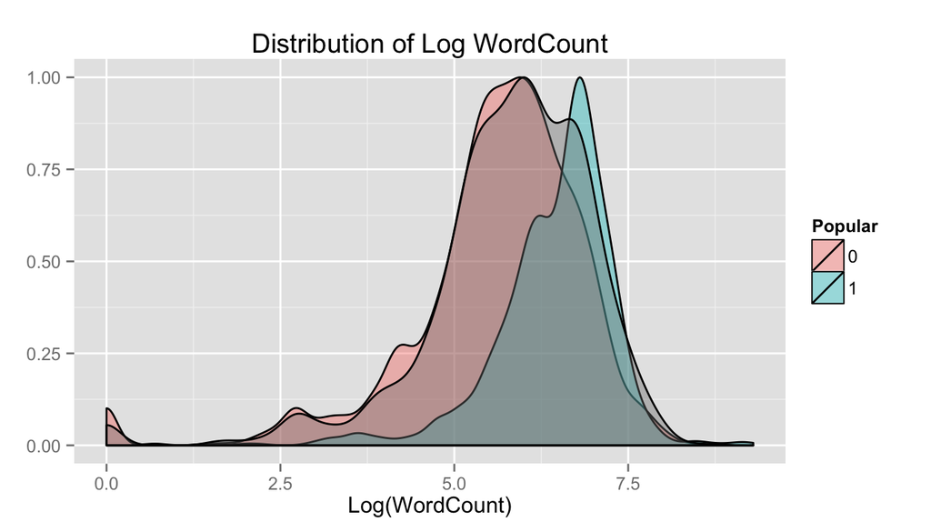

If we conduct a two-sided t-test on the mean and a two-sided F-test on the variance:

```r
PopularNewsTrain   = subset(newsTrain, newsTrain$Popular==1)
UnpopularNewsTrain = subset(newsTrain, newsTrain$Popular==0)

t.test(PopularNewsTrain$LogWordCount, UnpopularNewsTrain$LogWordCount)
```

```
##
##  Welch Two Sample t-test
##
## data:  PopularNewsTrain$LogWordCount and UnpopularNewsTrain$LogWordCount
## t = 28.2691, df = 2310.719, p-value < 2.2e-16
## alternative hypothesis: true difference in means is not equal to 0
## 95 percent confidence interval:
##  0.8018917 0.9214367
## sample estimates:
## mean of x mean of y
##  6.455548  5.593884
```

```r
var.test(PopularNewsTrain$LogWordCount, UnpopularNewsTrain$LogWordCount)
```

```
##
##  F test to compare two variances
##
## data:  PopularNewsTrain$LogWordCount and UnpopularNewsTrain$LogWordCount
## F = 0.4108, num df = 1092, denom df = 5438, p-value < 2.2e-16
## alternative hypothesis: true ratio of variances is not equal to 1
## 95 percent confidence interval:
##  0.3752262 0.4509859
## sample estimates:
## ratio of variances
##          0.4107796
```

This shows us there is a statistically significant difference between popular and unpopular articles based on the word counts. At the same time, popular article seems having shorter `Headline`.

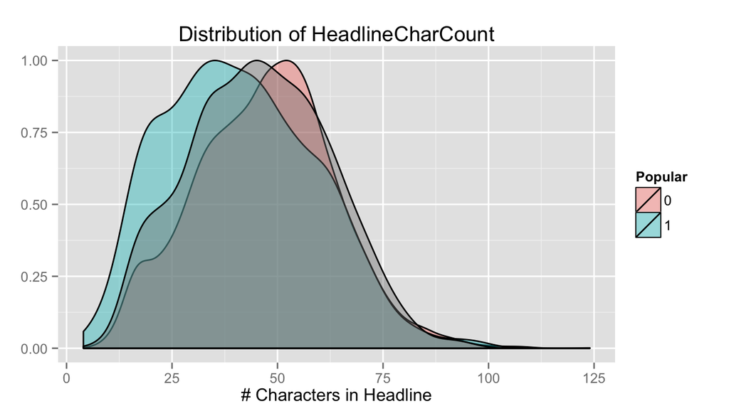

```r
t.test(PopularNewsTrain$HeadlineCharCount, UnpopularNewsTrain$HeadlineCharCount)
```

```
##
##  Welch Two Sample t-test
##
## data:  PopularNewsTrain$HeadlineCharCount and UnpopularNewsTrain$HeadlineCharCount
## t = -10.4608, df = 1483.142, p-value < 2.2e-16
## alternative hypothesis: true difference in means is not equal to 0
## 95 percent confidence interval:
##  -7.191321 -4.920218
## sample estimates:
## mean of x mean of y
##  41.16651  47.22228
```

##### Publishing Hour and Day

It is unlikely that many article receiving 25 more comments in the middle of night. Hence, at certain times during the day, we expect the probability that a random article becomes popular to be larger. Similarly, the day of the week may have an impact, people may have much more time to read articles than a working day.

```r
## date feature
newsData$PubDate = strptime(newsData$PubDate, "%Y-%m-%d %H:%M:%S")
newsData$PubDay  = as.Date(newsData$PubDate)
## it is expected that different behaviours at different times of the day.publication
newsData$DayofWeek = newsData$PubDate$wday
newsData$Hour    = newsData$PubDate$hour
newsData$DayOfWeek = as.factor(weekdays(newsData$PubDate))
newsData$DayOfWeek = factor(newsData$DayOfWeek, levels=c("Monday", "Tuesday", "Wednesday", "Thursday", "Friday", "Saturday", "Sunday"))

## especially on holidays, people may have much more time to read and comment on blog articles
Holidays = c(as.POSIXlt("2014-09-01 00:00", format="%Y-%m-%d %H:%M"),
             as.POSIXlt("2014-10-13 00:00", format="%Y-%m-%d %H:%M"),
             as.POSIXlt("2014-10-31 00:00", format="%Y-%m-%d %H:%M"),
             as.POSIXlt("2014-11-11 00:00", format="%Y-%m-%d %H:%M"),
             as.POSIXlt("2014-11-27 00:00", format="%Y-%m-%d %H:%M"),
             as.POSIXlt("2014-12-24 00:00", format="%Y-%m-%d %H:%M"),
             as.POSIXlt("2014-12-25 00:00", format="%Y-%m-%d %H:%M"),
             as.POSIXlt("2014-12-31 00:00", format="%Y-%m-%d %H:%M"))

newsData$Holiday = as.factor(ifelse(newsData$PubDate$yday %in% Holidays$yday, 1, 0))
```

```
##    Unpopular Popular PopularDensity Hour
## 4        169       2     0.01169591    4
## 5        240      11     0.04382470    5
## 3         57       3     0.05000000    3
## 7        369      25     0.06345178    7
## 1         25       3     0.10714286    1
## 8        299      39     0.11538462    8
## 2         21       3     0.12500000    2
## 13       390      57     0.12751678   13
## 17       348      52     0.13000000   17
## 6        190      30     0.13636364    6
## 9        267      49     0.15506329    9
## 16       382      74     0.16228070   16
## 14       375      77     0.17035398   14
## 0        103      22     0.17600000    0
## 10       315      69     0.17968750   10
## 12       428      94     0.18007663   12
## 18       269      60     0.18237082   18
## 11       414      93     0.18343195   11
## 15       345      93     0.21232877   15
## 19       140      53     0.27461140   19
## 20       114      44     0.27848101   20
## 21        76      34     0.30909091   21
## 23        46      21     0.31343284   23
## 22        57      85     0.59859155   22
```

It seems that publishing blog posts around `10 pm` are more easier getting popular according to `PopularDensity`. But, if we compare number of popular articles of 24 hours, It is clear to see that around `12 pm` and `3 pm`, even more blog posts receiving 25 more comments than `10 pm`.

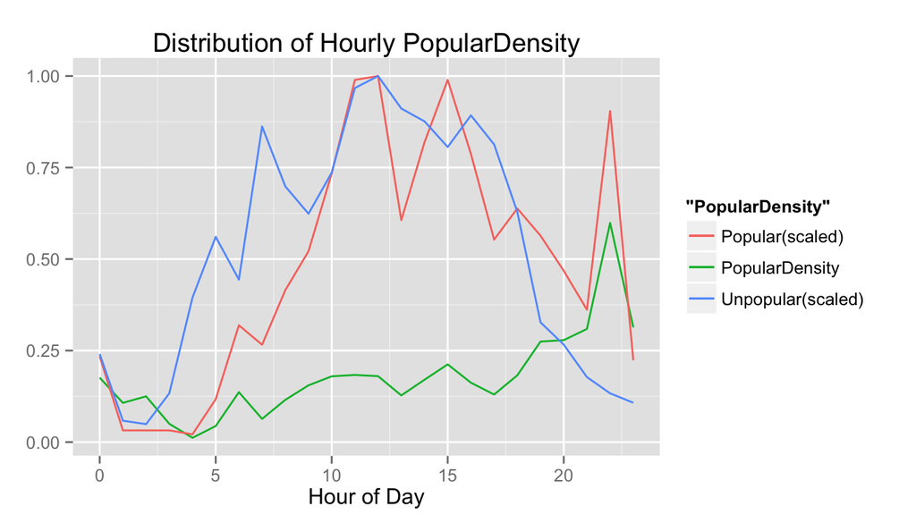

```
##           Unpopular Popular PopularDensity Day
## Friday         1003     161      0.1383162   5
## Tuesday        1016     174      0.1462185   2
## Thursday       1033     195      0.1587948   4
## Wednesday      1027     197      0.1609477   3
## Monday         1010     214      0.1748366   1
## Saturday        138      52      0.2736842   6
## Sunday          212     100      0.3205128   7
```

Similarly, day of week shows same trends as hourly results. Also, much more articles are published on weekday than weekends.

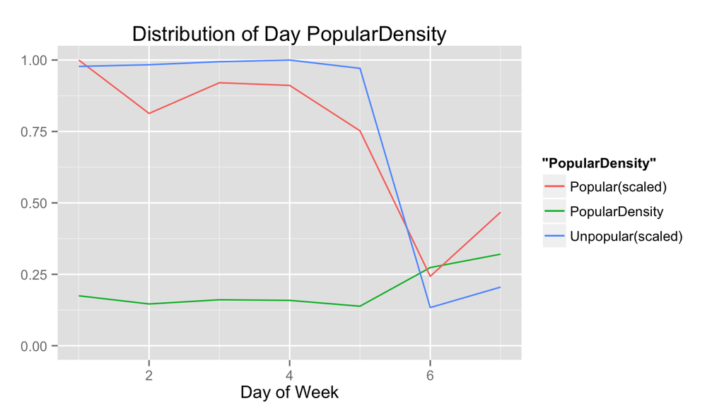

##### Category of Articles

There are three variables categorizes blog posts, `NewsDesk` `SectionName` and `SubsectionName`.

```r
## missing categories
misCategory = subset(newsData, newsData$NewsDesk=="" | newsData$SectionName=="" | newsData$SubsectionName=="")
dim(misCategory)[1]
```

```
## [1] 6721
```

```r
misCategory = subset(newsData, newsData$NewsDesk=="" & newsData$SectionName=="" & newsData$SubsectionName=="")
dim(misCategory)[1]
```

```
## [1] 1626
```

**6721** articles have at one category variable missing and **1626** articles have no categories at all. After filling blank categories based on existing category variables, let’s try to see the facet distribution of blog posts.

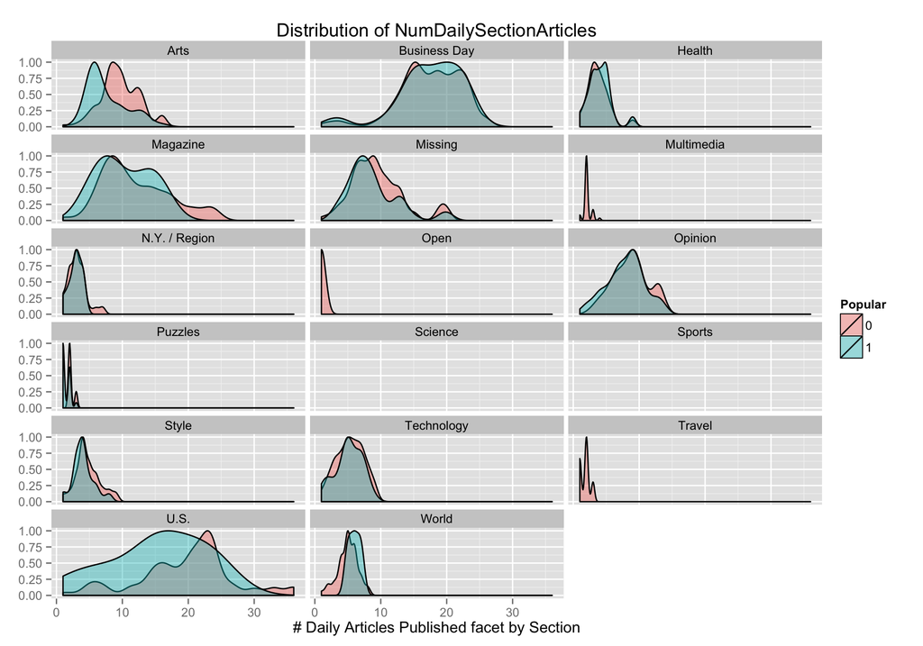

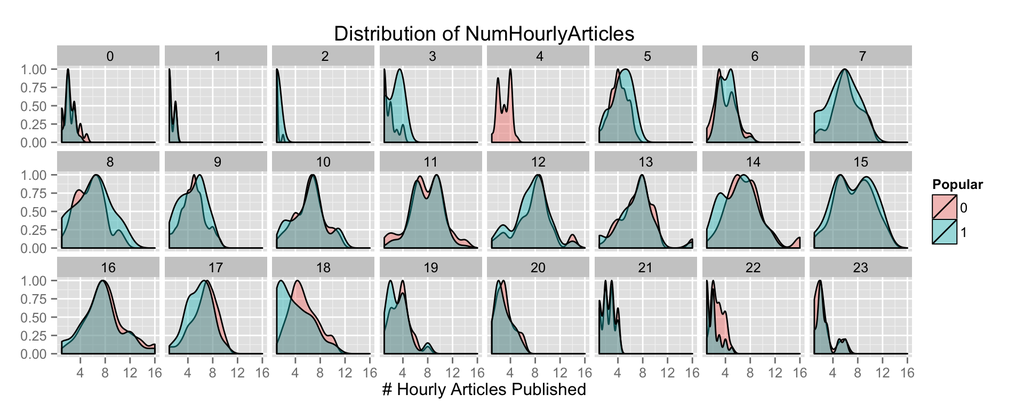

##### Contents Features of Articles

Until now, we preprocessed date features, word counts and categories of article. Almost all features from original data frame but the contents of blog post.

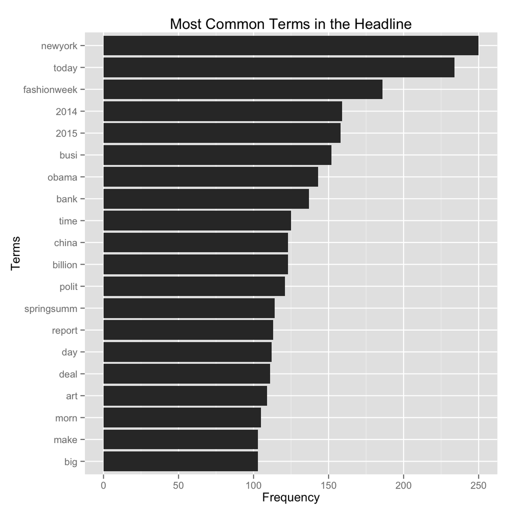

```r
stopWords = c(stopwords("SMART"))
CorpusText = Corpus(VectorSource(newsData$Headline))
CorpusText = tm_map(CorpusText, tolower)
CorpusText = tm_map(CorpusText, PlainTextDocument)
CorpusText = tm_map(CorpusText, removePunctuation)
CorpusText = tm_map(CorpusText, removeWords, stopWords)
CorpusText = tm_map(CorpusText, stemDocument, language="english")

tdmText = TermDocumentMatrix(CorpusText)
# around 20 words
sparseText = removeSparseTerms(tdmText, 0.989)
sparseText = as.data.frame(as.matrix(sparseText))
colnames(sparseText) = make.names(colnames(sparseText))

dtmText = DocumentTermMatrix(CorpusText)
freqTerms = findFreqTerms(dtmText, lowfreq=10)
termFreq  = colSums(as.matrix(dtmText))
termFreq  = subset(termFreq, termFreq>=100)
df        = data.frame(term=names(termFreq), freq=termFreq)

## Bag of Words
newsDataBoW = newsData
newsDataBoW$PubDate = NULL

tSparseText = t(sparseText)
colnames(tSparseText) = make.names(paste('c',colnames(tSparseText),sep="_"))
newsDataBoW[, colnames(tSparseText)] = tSparseText
```

### Modeling Data

##### Logistic Regression without contents feature

```r
# MODEL--0
# LR_0
# finding importance of features
removedColumns = c("SectionName", "NewsDesk", "SubsectionName", "Headline", "Snippet", "Abstract", "Summary", "UniqueID", "Text", "PopularFactor")
LR_0 = glm(Popular ~ ., data=newsTrain[,!colnames(newsTrain) %in% removedColumns], family=binomial)

calcAUClr(LR_0, newsTrain$Popular)
```

```
## [1] 0.9015615 0.9315814
```

```r
# training result: 0.9315814
LR_0_Pred = predict(LR_0, newdata=newsTest[, !colnames(newsTrain) %in% removedColumns], type="response")
generateSubmission(LR_0_Pred, submitPath)
# testing  result: 0.89088

summary(LR_0)
```

```
##
## Call:
## glm(formula = Popular ~ ., family = binomial, data = newsTrain[,
##     !colnames(newsTrain) %in% removedColumns])
##
## Deviance Residuals:
##     Min       1Q   Median       3Q      Max
## -2.8005  -0.3645  -0.1895  -0.0059   3.4498
##
## Coefficients: (12 not defined because of singularities)
##                                         Estimate Std. Error z value
## (Intercept)                            3.885e+00  4.792e+02   0.008
## PubDay                                 1.131e-04  1.940e-03   0.058
## Hour                                   3.572e-02  9.917e-03   3.601
## WordCount                              3.052e-04  1.462e-04   2.088
## HeadlineCharCount                     -1.409e-02  8.095e-03  -1.741
## SummaryCharCount                      -1.544e-02  4.066e-03  -3.797
## HeadlineWordCount                      1.080e-01  4.170e-02   2.589
## SummaryWordCount                       7.890e-02  2.350e-02   3.357
## LogWordCount                           8.855e-01  1.073e-01   8.253
## ShortHeadline1                         8.897e-02  1.647e-01   0.540
## DayofWeek                             -5.135e-01  3.607e-01  -1.424
## DayOfWeekTuesday                       1.740e-01  4.397e-01   0.396
## DayOfWeekWednesday                     8.961e-01  7.822e-01   1.146
## DayOfWeekThursday                      1.272e+00  1.128e+00   1.128
## DayOfWeekFriday                        1.625e+00  1.500e+00   1.083
## DayOfWeekSaturday                      2.324e+00  2.123e+00   1.095
## DayOfWeekSunday                               NA         NA      NA
## Holiday1                              -9.462e-02  2.385e-01  -0.397
## SectionNameFactorBusiness Day         -1.397e+01  4.781e+02  -0.029
## SectionNameFactorHealth               -1.547e+01  6.523e+03  -0.002
## SectionNameFactorMagazine             -1.593e+00  3.993e-01  -3.990
## SectionNameFactorMissing               2.868e-01  1.159e+00   0.247
## SectionNameFactorMultimedia           -2.263e+00  1.379e+00  -1.641
## SectionNameFactorN.Y. / Region         6.207e-02  3.405e-01   0.182
## SectionNameFactorOpen                 -1.582e+01  3.104e+03  -0.005
## SectionNameFactorOpinion               4.031e+00  2.187e-01  18.430
## SectionNameFactorPuzzles               3.368e+00  3.537e-01   9.523
## SectionNameFactorScience               2.554e+00  7.987e+03   0.000
## SectionNameFactorSports               -1.827e+01  4.607e+03  -0.004
```

[output cut: 83 more lines]

```
## SubsectionNameFactorSmall Business          NA
## SubsectionNameFactorThe Public Editor 0.977166
## NumDailyArticles                      0.298318
## NumDailySectionArticles               0.006239 **
## NumHourlyArticles                     0.003480 **
## ---
## Signif. codes:  0 '***' 0.001 '**' 0.01 '*' 0.05 '.' 0.1 ' ' 1
##
## (Dispersion parameter for binomial family taken to be 1)
##
##     Null deviance: 5900.1  on 6531  degrees of freedom
## Residual deviance: 3093.0  on 6486  degrees of freedom
## AIC: 3185
##
## Number of Fisher Scoring iterations: 17
```

By using `summary(Model)`, we can select the following variables based on importance of variables.

```r
selectedColumns = c("Popular",
                    "PubDay",
                    "Hour",
                    "LogWordCount",
                    "SummaryCharCount",
                    "HeadlineWordCount",
                    "WordCount",
                    "SummaryCharCount",
                    "HeadlineCharCount",
                    "SectionNameFactor",
                    "SubsectionNameFactor",
                    "NumDailySectionArticles",
                    "NumHourlyArticles")
```

###### MODEL-1 (logistic regression)

```r
LR_1 = glm(Popular ~ ., data=newsTrain[, colnames(newsTrain) %in% selectedColumns], family=binomial)

calcAUClr(LR_1, newsTrain$Popular)
# training result: 0.9297705

LR_1_Pred = predict(LR_1, newdata=newsTest[, colnames(newsTrain) %in% selectedColumns], type="response")
generateSubmission(LR_1_Pred, submitPath)
# testing  result: 0.89212
```

###### MODEL-2 (random forest)

```r
RF_2 = randomForest(Popular ~ ., data=newsTrain[, colnames(newsTrain) %in% selectedColumns], nodesize=1, ntree=2500, importance=TRUE)

trainPartition = createDataPartition(y=newsTrain$Popular, p=0.5, list=FALSE)
tuneTrain      = newsTrain[trainPartition, colnames(newsTrain) %in% selectedColumns]
RF_2.tuned  = train(Popular ~ ., data=tuneTrain, method="rf", trControl=trainControl(method="cv", number=5))

calcAUC(RF_2, newsTrain$Popular)
# training result: 0.9387521

RF_2_Pred = predict(RF_2, newdata=newsTest, type="prob")[,2]
generateSubmission(RF_2_Pred, submitPath)
# testing  result: 0.89470
```

###### MODEL-3 (logistic regression on Bag of Words)

```r
LR_3 = glm(Popular ~ ., data=newsTrainBoW[,!colnames(newsTrainBoW) %in% removedColumns], family=binomial)
calcAUClr(LR_3, newsTrainBoW$Popular)
# training result: 0.9389116

LR_3_Pred = predict(LR_3, newdata=newsTestBoW, type="response")
generateSubmission(LR_3_Pred, submitPath)
# testing  result: 0.90176
```

###### MODEL-4 (random forest on Bag of Words)

```r
RF_4 = randomForest(Popular ~ ., data=newsTrainBoW[,!colnames(newsTrainBoW) %in% removedColumns], nodesize=5, ntree=2500, importance=TRUE)

trainPartition = createDataPartition(y=newsTrainBoW$Popular, p=0.5, list=FALSE)
tuneTrain      = newsTrainBoW[trainPartition,!colnames(newsTrainBoW) %in% removedColumns]
RF_4.tuned  = train(Popular ~ ., data=tuneTrain, method="rf", trControl=trainControl(method="cv", number=5))

calcAUC(RF_4, newsTrainBoW$Popular)
# training result: 0.9399500

RF_4_Pred = predict(RF_4, newdata=newsTestBoW, type="prob")[,2]
generateSubmission(RF_4_Pred, submitPath)
# testing  result: 0.90048
```

##### Supervised + Unsupervised

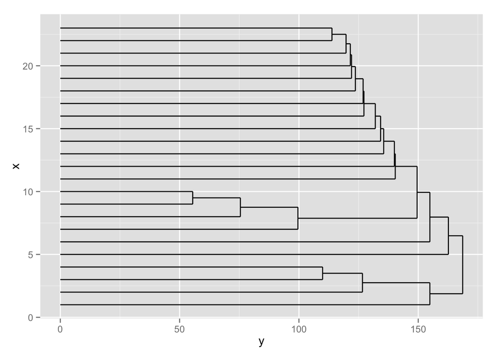

```r
matrixSparseText  = as.matrix(sparseText)
matrixSparseText.distMatrix = dist(scale(matrixSparseText))
matrixSparseText.clusters   = hclust(matrixSparseText.distMatrix, method="ward.D2")

dText = as.dendrogram(matrixSparseText.clusters)
dTextData <- dendro_data(dText, type = "rectangle")

ggplot(segment(dTextData)) +
  geom_segment(aes(x = x, y = y, xend = xend, yend = yend)) + coord_flip()
```

```r
kText   = 25
mText   = t(sparseText)
KMCText = kmeans(mText, kText)

for (i in 1:kText) {
  cat(paste("cluster", i, ": ", sep=" "))
  s = sort(KMCText$centers[i, ], decreasing=TRUE)
  cat(names(s)[1:15], sep=", ", "\n")
}

newsData$TextCluster     = as.factor(KMCText$cluster)
newsData$PubDate = NULL
newsTrain = head(newsData, nrow(trainData))
newsTest  = tail(newsData, nrow(testData))
```

###### MODEL-5 (random forest on text cluster)

```r
selectedColumns = cbind(selectedColumns, c("TextCluster"))
RF_5 = randomForest(Popular ~ ., data=newsTrain[, colnames(newsTrain) %in% selectedColumns], nodesize=5, ntree=2500, importance=TRUE)

trainPartition = createDataPartition(y=newsTrain$Popular, p=0.5, list=FALSE)
tuneTrain      = newsTrain[trainPartition, colnames(newsTrain) %in% selectedColumns]
RF_5.tuned  = train(Popular ~ ., data=tuneTrain, method="rf", trControl=trainControl(method="cv", number=5))

calcAUC(RF_5, newsTrain$Popular)
# training result: 0.9399861

RF_5_Pred = predict(RF_5, newdata=newsTest, type="prob")[,2]
generateSubmission(RF_5_Pred, submitPath)
# testing  result: 0.89854
```

##### Features of negative example

```r
newsData$QAboutNews = as.factor(ifelse(grepl("6q", newsData$Text) == TRUE, 1, 0))
newsData$DailyClip = as.factor(ifelse(grepl("DailyClipReport", newsData$Text) == TRUE, 1, 0))
newsData$DailyReport = as.factor(ifelse(grepl("DailyReport", newsData$Text) == TRUE, 1, 0))
newsData$PicOfDay = as.factor(ifelse(grepl("PicOfDay", newsData$Text) == TRUE, 1, 0))
newsData$TestYourself = as.factor(ifelse(grepl("TestYourself", newsData$Text) == TRUE, 1, 0))
newsData$WordofDay = as.factor(ifelse(grepl("WordofDay", newsData$Text) == TRUE, 1, 0))
newsData$Recap = as.factor(ifelse(grepl("recap", newsData$Text) == TRUE, 1, 0))

newsTrain = head(newsData, nrow(trainData))
newsTest  = tail(newsData, nrow(testData))
```

###### MODEL-6 (logistic regression with negative example features)

```r
selectedColumns = cbind(selectedColumns, c("QAboutNews", "DailyClip", "DailyReport", "PicOfDay", "TestYourself", "WordofDay", "Recap"))

LR_6 = glm(Popular ~ ., data=newsTrain[, colnames(newsTrain) %in% selectedColumns], family=binomial)
calcAUClr(LR_6, newsTrain$Popular)

LR_6_Pred = predict(LR_6, newdata=newsTest[, colnames(newsTest) %in% selectedColumns], type="response")
generateSubmission(LR_6_Pred, submitPath)
```

###### MODEL-7 (random forest with negative example features)

```r
RF_7 = randomForest(Popular ~ ., data=newsTrain[, colnames(newsTrain) %in% selectedColumns], nodesize=5, ntree=2500, importance=TRUE)

trainPartition = createDataPartition(y=newsTrain$Popular, p=0.5, list=FALSE)
tuneTrain      = newsTrain[trainPartition, colnames(newsTrain) %in% selectedColumns]

RF_7.tuned  = train(Popular ~ ., data=tuneTrain, method="rf", trControl=trainControl(method="cv", number=5))

calcAUC(RF_7, newsTrain$Popular)
# training result: 0.9390981

RF_7_Pred = predict(RF_7, newdata=newsTest, type="prob")[,2]
generateSubmission(RF_7_Pred, submitPath)
# testing  result: 0.89867
```

##### Topic Words

Add some topic features according [Topic from Google](http://www.google.com/trends/topcharts#vm=cat&geo=US&date=2014&cid=travel_and_leisure).

```r
questionWords <- c("\\?","^why","should","^when","can","^if","^is")
religionWords <- c("secular","humanist","humanism","secularist","god","religion","atheist","atheism","islam","islamic","islamist",
              "islamists","church","atheists","jesus","christ","christian","catholic","pope","imam", "\\<isis\\>","muslim","gay","marriage","israel","jewish","extremist", "fundamentalism","terror","terrorist","terrorism")
techWords <- c("apple","\\<ios\\>","ipod", "ipad","iphone")
healthWords <- c("cancer","weight","fat","heart","disease","brain","sex","sexual","love","hate","doctor","doctors","medical","medicine","hospital","hospitals")
sciWords <- c("climate","warming","global","science","scientists")
busWords <- c("jobs","employment","work","working","economy")
poliHiWords <- c("republican", "conservative")

newsData$Question <- as.factor(ifelse(grepl(paste(questionWords, collapse="|"), newsData$Headline)==TRUE,1,0))
newsData$religionWords <- ifelse(grepl(paste(religionWords, collapse="|"), newsData$Headline)==TRUE,1,0)
newsData$tech <- ifelse(grepl(paste(techWords, collapse="|"), newsData$Headline)==TRUE,1,0)
newsData$health <- ifelse(grepl(paste(healthWords, collapse="|"), newsData$Headline)==TRUE,1,0)
newsData$sci <- ifelse(grepl(paste(sciWords, collapse="|"), newsData$Headline)==TRUE,1,0)
newsData$business <- ifelse(grepl(paste(busWords, collapse="|"), newsData$Headline)==TRUE,1,0)
newsData$poliHi <- ifelse(grepl(paste(poliHiWords, collapse="|"), newsData$Headline)==TRUE,1,0)
newsData$noComment <- ifelse(grepl("no comment necessary", newsData$Headline),1,0)
newsData$comments <- ifelse(grepl("open for comments", newsData$Headline),1,0)
```

MODEL-8 (logistic regression with topic words)

```r
LR_8 = glm(Popular ~ . - UniqueID, data=newsTrain, family=binomial)
calcAUClr(LR_8, newsTrain$Popular)
# training result: 0.9412723

LR_8_Pred = predict(LR_8, newdata=newsTest, type="response")
generateSubmission(LR_8_Pred, submitPath)
# testing  result: 0.89517
```

###### MODEL-9 (random forest with topic words)

```r
RF_9 = randomForest(Popular ~ . - UniqueID, data=newsTrain, nodesize=5, ntree=2500, importance=TRUE)
trainPartition = createDataPartition(y=newsTrain$Popular, p=0.5, list=FALSE)
tuneTrain      = newsTrain[trainPartition, ]
RF_9.tuned  = train(Popular ~ . - UniqueID, data=tuneTrain, method="rf", trControl=trainControl(method="cv", number=5))

calcAUC(RF_9, newsTrain$Popular)
# training result: 0.9418562

RF_9_Pred = predict(RF_9, newdata=newsTest, type="prob")[,2]
generateSubmission(RF_9_Pred, submitPath)
# testing  result: 0.89962
```

##### Model Evaluation

[output not shown]

##### Ensemble

```r
EN_1 = (2*RF_9_Pred + 3*RF_4_Pred + 1*LR_3_Pred)/6
EN_2 = (2*RF_4_Pred + 3*LR_3_Pred + 1*LR_3_Pred)/6
EN_3 = (2*LR_1_Pred + 3*RF_2_Pred + 1*LR_8_Pred)/6
EN_4 = (2*LR_6_Pred + 3*RF_5_Pred + 1*RF_7_Pred)/6
EN_5 = (2*RF_5_Pred + 3*RF_4_Pred + 1*LR_3_Pred)/6
EN_6 = (1*RF_4_Pred + 2*LR_3_Pred + 1*LR_3_Pred)/4

generateSubmission(EN_1, submitPath)
generateSubmission(EN_2, submitPath)
generateSubmission(EN_3, submitPath)
generateSubmission(EN_4, submitPath)
generateSubmission(EN_5, submitPath)
generateSubmission(EN_6, submitPath)
```

| Model Name | Test ROC |
| --- | --- |
| EN_1 | 0.90238 |
| EN_2 | **0.90550** |
| EN_3 | 0.89973 |
| EN_4 | 0.90361 |
| EN_5 | 0.90271 |
| EN_6 | 0.90529 |